# INFSCI 2595 Final Project

Interpretation

Radhika Purohit

```r
knitr::opts_chunk$set(echo = TRUE)
```

```r
library(tidyverse)
```

```r
theme_set(theme_linedraw())
library(tidymodels)
tidymodels_prefer()
library(vip)
```

```r
df <- readr::read_csv("paint_project_train_data.csv", col_names = TRUE)
dfii <- df %>%
  mutate(y = boot::logit( (response - 0) / (100 - 0) ) ) %>%
  select(R, G, B,
         Lightness, Saturation, Hue,
         y)

dfiiiA <- df %>%
  select(-response)


dfiiiD <- df %>%
  select(-response) %>%
  mutate(outcome = ifelse(outcome == 1, 'event', 'non_event'),
         outcome = factor(outcome, levels = c('event', 'non_event')))
```

Tasks - Identify the combinations of Lightness and Saturation that appear to be hardest to predict for the regression and classification tasks based on the best models.

## Hard to Predict

The best model for the **regression task** was the XGB model.  
The best model for the **classification task** was the XGB model.

**Read in the respective best model for each task.**

```r
mod_regr <- readr::read_rds("mod_2D_adv_best_wflow.rds")
mod_regr_resample <- readr::read_rds("mod_2D_adv_best_resample.rds")

mod_clas <- readr::read_rds("mod_3D_adv_best_wflow.rds")
mod_clas_resample <- readr::read_rds("mod_3D_adv_best_resample.rds")
```

## Regression

**Summarize the prediction error (MAE) across the resample repeated folds**

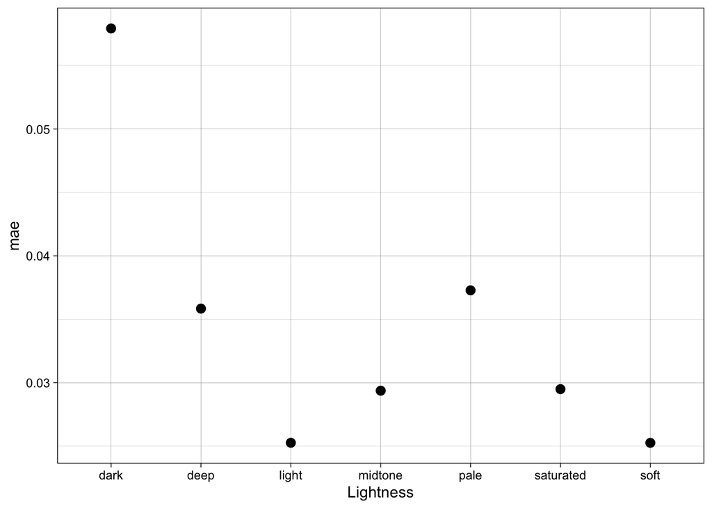

```r
regr_pred <- mod_regr_resample %>%
  # get all predictions across folds and repeats
  collect_predictions() %>%
  # join the training df
  left_join(rowid_to_column(select(dfii,-y)), by = c(".row" = "rowid"))

regr_pred %>%
  group_by(id, id2, Lightness) %>%
  mae(y, .pred) %>%
  group_by(Lightness) %>%
  summarise(mae = mean(.estimate)) %>%
  ggplot() +
  geom_pointrange(aes(
    x=Lightness,
    y=mae,
    ymax=mae,
    ymin = mae,
    ))
```

- The combination of Lightness with dark is the most difficult to predict using the best regression model.
- The combination of Lightness with light is the easiest to predict using the best regression model.

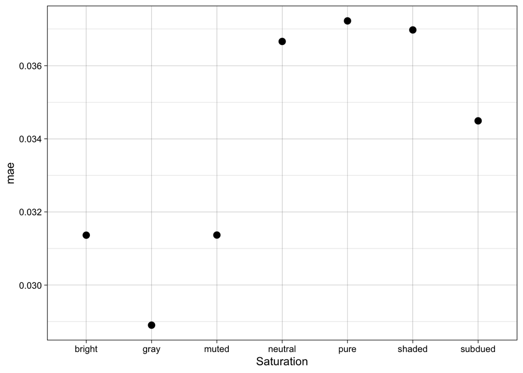

```r
regr_pred <- mod_regr_resample %>%
  # get all predictions across folds and repeats
  collect_predictions() %>%
  # join the training df
  left_join(rowid_to_column(select(dfii,-y)), by = c(".row" = "rowid"))

regr_pred %>%
  group_by(id, id2, Saturation) %>%
  mae(y, .pred) %>%
  group_by(Saturation) %>%
  summarise(mae = mean(.estimate)) %>%
  ggplot() +
  geom_pointrange(aes(
    x=Saturation,
    y=mae,
    ymax=mae,
    ymin = mae,
    ))
```

## Classification

**Summarize the mean log loss across the resample repeated folds**

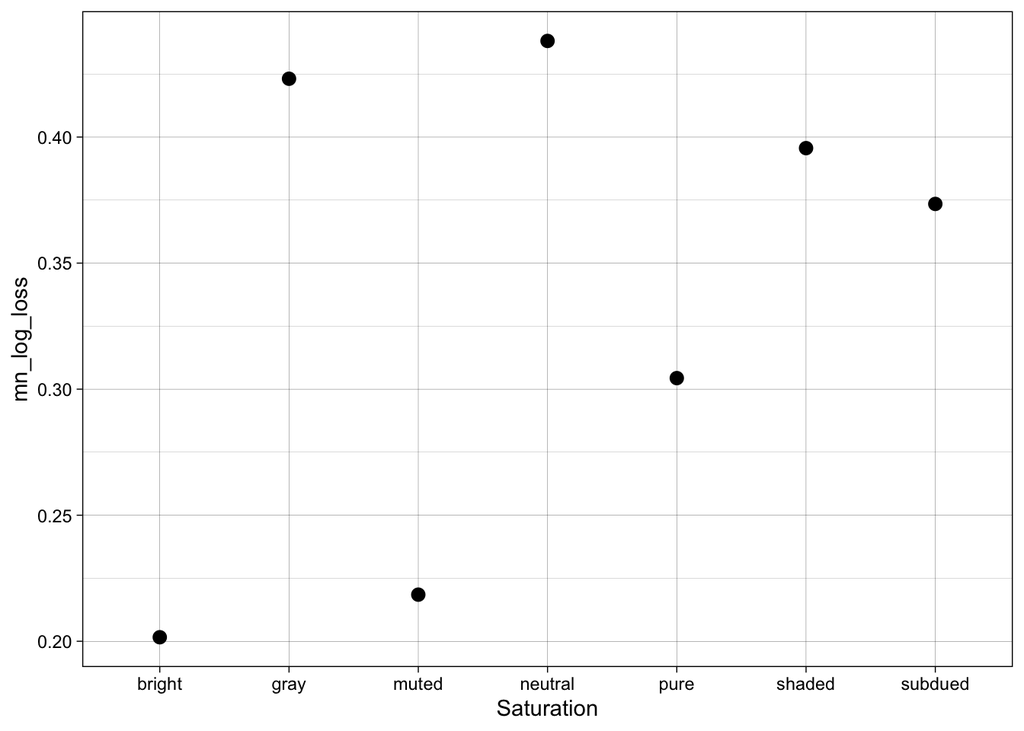

```r
clas_pred <- mod_clas_resample %>%
  # get all predictions across folds and repeats
  collect_predictions() %>%
  # join the training df
  left_join(rowid_to_column(select(dfii,-y)), by = c(".row" = "rowid"))

clas_pred %>%
  group_by(id, id2, Saturation) %>%
  mn_log_loss(outcome, .pred_event) %>%
  group_by(Saturation) %>%
  summarise(mn_log_loss = mean(.estimate)) %>%
  ggplot() +
  geom_pointrange(aes(
    x=Saturation,
    y=mn_log_loss,
    ymax=mn_log_loss,
    ymin = mn_log_loss,
    ))
```

- The combination of Saturation with neutral is the most difficult to predict using the best classification model.
- The combination of Saturation with bright is the easiest to predict using the best classification model.

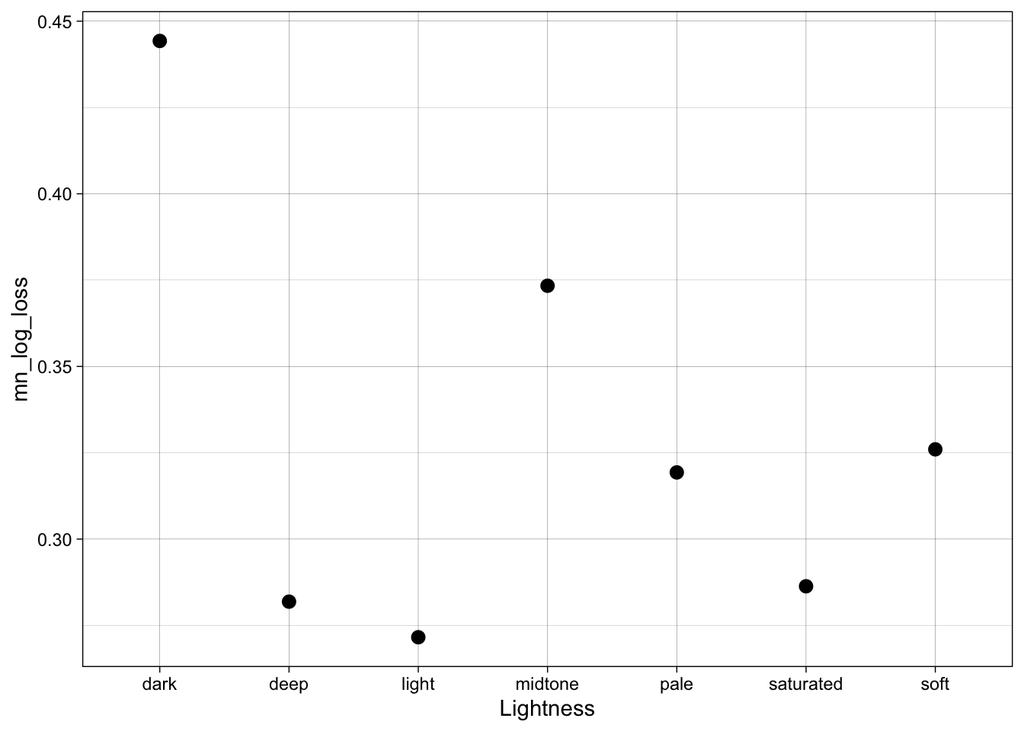

```r
clas_pred %>%
  group_by(id, id2, Lightness) %>%
  mn_log_loss(outcome, .pred_event) %>%
  group_by(Lightness) %>%
  summarise(mn_log_loss = mean(.estimate)) %>%
  ggplot() +
  geom_pointrange(aes(
    x=Lightness,
    y=mn_log_loss,
    ymax=mn_log_loss,
    ymin = mn_log_loss,
    ))
```

- The combination of Lightness with dark is the most difficult to predict using the best classification model.  
- The combination of Lightness with light is the easiest to predict using the best classification model.